```python
import matplotlib.pyplot as plt
import numpy as np
import pandas as pd
import matplotlib

import matplotlib.pyplot as plt


%config InlineBackend.figure_format = 'retina' #set 'png' here when working on notebook
%matplotlib inline
%config IPCompleter.greedy=True
```

# Election

## Read DF

```python
uri = 'eleicoes_2006_a_2010.csv'

df = pd.read_csv(uri)

df.head()
```

|  | ano | sequencial_candidato | nome | uf | partido | quantidade_doacoes | quantidade_doadores | total_receita | media_receita | recursos_de_outros_candidatos/comites | ... | quantidade_despesas | quantidade_fornecedores | total_despesa | media_despesa | cargo | sexo | grau | estado_civil | ocupacao | votos |
| --- | --- | --- | --- | --- | --- | --- | --- | --- | --- | --- | --- | --- | --- | --- | --- | --- | --- | --- | --- | --- | --- |
| 0 | 2006 | 10001 | JOSÉ LUIZ NOGUEIRA DE SOUSA | AP | PT | 6 | 6 | 16600.00 | 2766.666667 | NaN | ... | 14 | 14 | 16583.60 | 1184.542857 | DEPUTADO FEDERAL | MASCULINO | ENSINO MÉDIO COMPLETO | CASADO(A) | VEREADOR | 8579 |
| 1 | 2006 | 10002 | LOIVA DE OLIVEIRA | RO | PT | 13 | 13 | 22826.00 | 1755.846154 | 6625.0 | ... | 24 | 23 | 20325.99 | 883.738696 | DEPUTADO FEDERAL | FEMININO | SUPERIOR COMPLETO | SOLTEIRO(A) | SERVIDOR PÚBLICO ESTADUAL | 2757 |
| 2 | 2006 | 10002 | MARIA DALVA DE SOUZA FIGUEIREDO | AP | PT | 17 | 16 | 148120.80 | 9257.550000 | 2250.0 | ... | 123 | 108 | 146011.70 | 1351.960185 | DEPUTADO FEDERAL | FEMININO | SUPERIOR COMPLETO | VIÚVO(A) | PEDAGOGO | 17428 |
| 3 | 2006 | 10002 | ROMALDO MILANI | MS | PRONA | 6 | 6 | 3001.12 | 500.186667 | NaN | ... | 8 | 8 | 3001.12 | 375.140000 | DEPUTADO FEDERAL | MASCULINO | ENSINO MÉDIO INCOMPLETO | CASADO(A) | MILITAR REFORMADO | 1193 |
| 4 | 2006 | 10003 | ANSELMO DE JESUS ABREU | RO | PT | 48 | 48 | NaN | NaN | NaN | ... | 133 | 120 | 116416.64 | 970.138667 | DEPUTADO FEDERAL | MASCULINO | ENSINO FUNDAMENTAL COMPLETO | CASADO(A) | DEPUTADO | 29401 |

5 rows × 23 columns

### Removing non representative data

```python
df.columns
```

```
Index(['ano', 'sequencial_candidato', 'nome', 'uf', 'partido',
       'quantidade_doacoes', 'quantidade_doadores', 'total_receita',
       'media_receita', 'recursos_de_outros_candidatos/comites',
       'recursos_de_pessoas_fisicas', 'recursos_de_pessoas_juridicas',
       'recursos_proprios', 'quantidade_despesas', 'quantidade_fornecedores',
       'total_despesa', 'media_despesa', 'cargo', 'sexo', 'grau',
       'estado_civil', 'ocupacao', 'votos'],
      dtype='object')
```

```python
df.drop(labels=['partido','ano', 'sequencial_candidato', 'nome', 'uf', 'ocupacao', 'cargo' ], axis=1, inplace=True)
```

## Check Missing Values

```python
df.isnull().any()
```

```
quantidade_doacoes                       False
quantidade_doadores                      False
total_receita                             True
media_receita                             True
recursos_de_outros_candidatos/comites     True
recursos_de_pessoas_fisicas               True
recursos_de_pessoas_juridicas             True
recursos_proprios                         True
quantidade_despesas                      False
quantidade_fornecedores                  False
total_despesa                            False
media_despesa                            False
sexo                                     False
grau                                     False
estado_civil                             False
votos                                    False
dtype: bool
```

```python
df.isnull().sum()
```

```
quantidade_doacoes                          0
quantidade_doadores                         0
total_receita                             161
media_receita                             161
recursos_de_outros_candidatos/comites    2390
recursos_de_pessoas_fisicas              2683
recursos_de_pessoas_juridicas            3976
recursos_proprios                        2388
quantidade_despesas                         0
quantidade_fornecedores                     0
total_despesa                               0
media_despesa                               0
sexo                                        0
grau                                        0
estado_civil                                0
votos                                       0
dtype: int64
```

#### Dealing with missing values

Ok, so columns:

- recursos_de_outros_candidatos/comites 2390
- recursos_de_pessoas_fisicas 2683
- recursos_de_pessoas_juridicas 3976
- recursos_proprios 2388

Have too many missing data. Unfortunatelly, I Really dont know a better way to deal with this other than droping them completely :[

However, columns:

- total_receita 161
- media_receita 161

Have far less missing values. In fact, I believe that they are quite important ones. So I will turn a blind eye and fill the missing values with the mean of the column itself. ;]

```python
df.drop(labels=['recursos_de_outros_candidatos/comites', 'recursos_de_pessoas_fisicas', 'recursos_de_pessoas_juridicas', 'recursos_proprios'], axis=1, inplace=True)
df.fillna(df.mean(), inplace=True)
```

## Check Variance

```python
numeric_feats = df.dtypes[df.dtypes != "object"].index

numerics = df[numeric_feats]

numerics.max() - numerics.min()
```

```
quantidade_doacoes            6996.00
quantidade_doadores           5799.00
total_receita              4539726.64
media_receita               500180.00
quantidade_despesas           9931.00
quantidade_fornecedores       8358.00
total_despesa              4989490.86
media_despesa               500177.00
votos                      1353818.00
dtype: float64
```

- quantidade_doacoes
- quantidade_doadores
- total_receita
- media_receita
- quantidade_despesas
- quantidade_fornecedores
- total_despesa
- media_despesa
- votos

## Check Skewness

```
array([[<matplotlib.axes._subplots.AxesSubplot object at 0x7f0fba3045c0>,
      dtype=object)
```

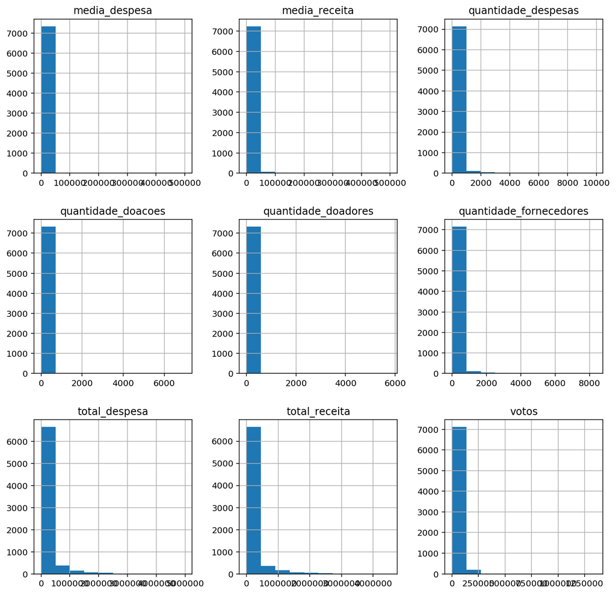

```python
high_var = pd.DataFrame({"votos":df["votos"], "total_despesa":df["total_despesa"],
                        "media_despesa":df["media_despesa"], "quantidade_fornecedores":df["quantidade_fornecedores"],
                         "quantidade_despesas":df["quantidade_despesas"],"media_receita":df["media_receita"],
                         "total_receita":df["total_receita"],"quantidade_doadores":df["quantidade_doadores"],
                         "quantidade_doacoes":df["quantidade_doacoes"]})

matplotlib.rcParams['figure.figsize'] = (12.0, 12.0)

high_var.hist()
```

P.S.: Yeah, not the best plot of my life

```python
from scipy.stats import skew


numeric_feats = numeric_feats.drop('votos')
skewed_feats = df[numeric_feats].apply(lambda x: skew(x.dropna()))
print(skewed_feats)
```

```
quantidade_doacoes         39.974077
quantidade_doadores        37.534080
total_receita               4.650381
media_receita              12.238452
quantidade_despesas         8.544328
quantidade_fornecedores     8.423145
total_despesa               4.534031
media_despesa              66.365637
dtype: float64
```

All of them have pretty high positive skewness, I will therefore apply **Logarithm transformation**

[data transformation](https://medium.com/@TheDataGyan/day-8-data-transformation-skewness-normalization-and-much-more-4c144d370e55)

[pipeline](https://www.kaggle.com/apapiu/regularized-linear-models)

```python
df[skewed_feats.index] =  np.log1p(df[skewed_feats.index])
```

```
array([[<matplotlib.axes._subplots.AxesSubplot object at 0x7f0fae1c2278>,
      dtype=object)
```

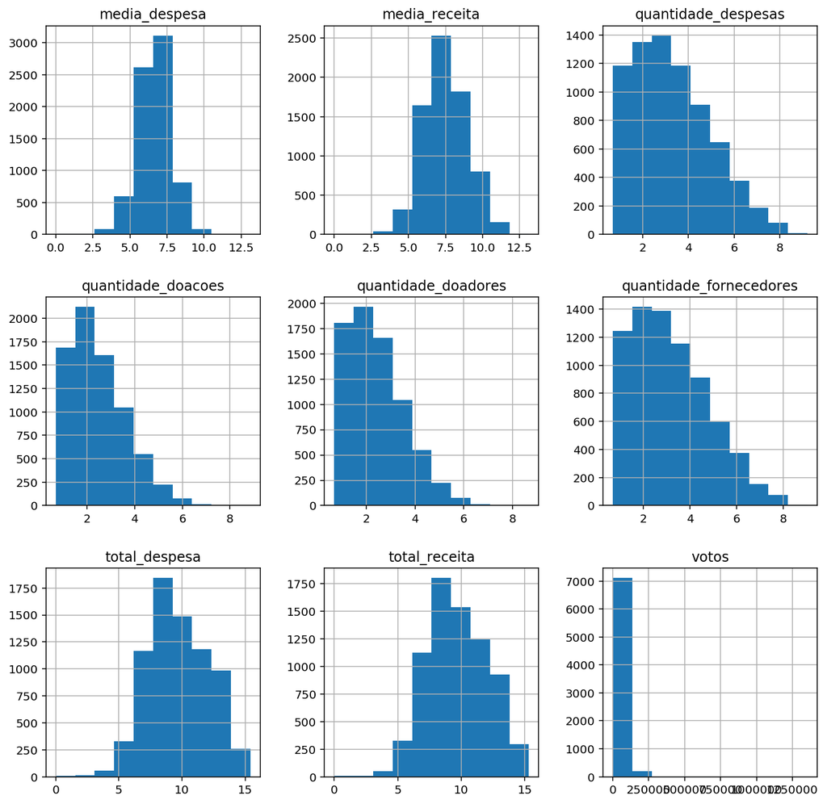

```python
log_transformed = pd.DataFrame({"votos":df["votos"], "total_despesa":df["total_despesa"],
                        "media_despesa":df["media_despesa"], "quantidade_fornecedores":df["quantidade_fornecedores"],
                         "quantidade_despesas":df["quantidade_despesas"],"media_receita":df["media_receita"],
                         "total_receita":df["total_receita"],"quantidade_doadores":df["quantidade_doadores"],
                         "quantidade_doacoes":df["quantidade_doacoes"]})

matplotlib.rcParams['figure.figsize'] = (12.0, 12.0)

log_transformed.hist()
```

##### That is some improvement =]

## One-hot enconding

```python
df = pd.get_dummies(df)
```

```python
df.columns
```

```
Index(['quantidade_doacoes', 'quantidade_doadores', 'total_receita',
       'media_receita', 'quantidade_despesas', 'quantidade_fornecedores',
       'total_despesa', 'media_despesa', 'votos', 'sexo_FEMININO',
       'sexo_MASCULINO', 'grau_ENSINO FUNDAMENTAL COMPLETO',
       'grau_ENSINO FUNDAMENTAL INCOMPLETO', 'grau_ENSINO MÉDIO COMPLETO',
       'grau_ENSINO MÉDIO INCOMPLETO', 'grau_LÊ E ESCREVE',
       'grau_SUPERIOR COMPLETO', 'grau_SUPERIOR INCOMPLETO',
       'estado_civil_CASADO(A)', 'estado_civil_DIVORCIADO(A)',
       'estado_civil_SEPARADO(A) JUDICIALMENTE', 'estado_civil_SOLTEIRO(A)',
       'estado_civil_VIÚVO(A)'],
      dtype='object')
```

### Remove multicollinearity

```python
df.drop(labels=['grau_SUPERIOR COMPLETO', 'estado_civil_SOLTEIRO(A)', 'sexo_MASCULINO'], axis=1, inplace=True)
```

## Train/Test Split

```python
from sklearn.model_selection import train_test_split


data = df.copy()
target = data.pop('votos')

X_train, X_test, y_train, y_test = train_test_split(data, target, shuffle=True,
                                                    test_size=0.5, random_state=49)
```

## Fit Model on Training Data

```python
from sklearn.linear_model import LinearRegression


lr_train = LinearRegression(fit_intercept=True)
lr_train.fit(X_train, y_train)
```

```
LinearRegression(copy_X=True, fit_intercept=True, n_jobs=1, normalize=False)
```

```python
from sklearn.metrics import mean_squared_error

def calc_ISE(X_train, y_train, model):
    '''returns the in-sample R^2 and RMSE; assumes model already fit.'''
    predictions = model.predict(X_train)
    mse = mean_squared_error(y_train, predictions)
    rmse = np.sqrt(mse)
    return model.score(X_train, y_train), rmse



def calc_OSE(X_test, y_test, model):
    '''returns the out-of-sample R^2 and RMSE; assumes model already fit.'''
    predictions = model.predict(X_test)
    mse = mean_squared_error(y_test, predictions)
    rmse = np.sqrt(mse)
    return model.score(X_test, y_test), rmse
```

```python
coef = pd.Series(lr_train.coef_, index = X_train.columns)
```

```python
imp_coef = pd.concat([coef.sort_values().head(20),
                     coef.sort_values().tail(20)])
```

```
Text(0.5,1,'Coefficients in the Linear Regression Model')
```

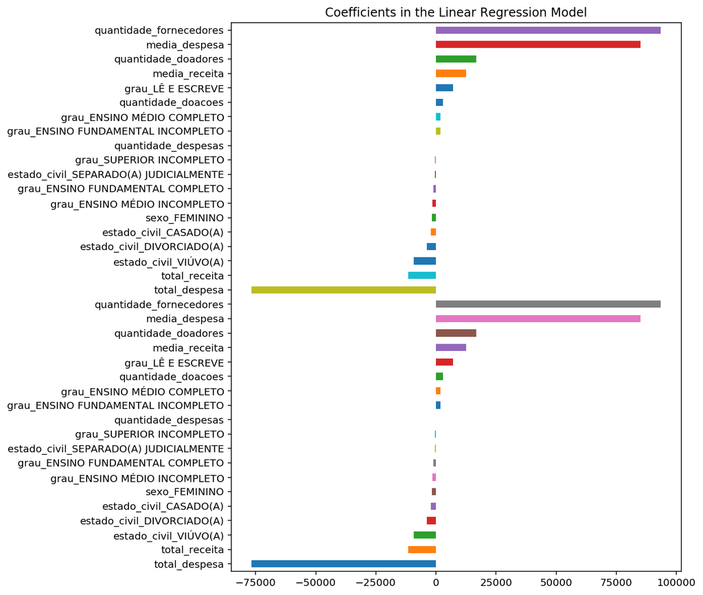

```python
matplotlib.rcParams['figure.figsize'] = (8.0, 10.0)
imp_coef.plot(kind = "barh")
plt.title("Coefficients in the Linear Regression Model")
```

```python
is_r2, ise = calc_ISE(X_train, y_train, lr_train)
os_r2, ose = calc_OSE(X_test, y_test, lr_train)

# show dataset sizes
data_list = (('R^2_in', is_r2), ('R^2_out', os_r2),
             ('ISE', ise), ('OSE', ose))
for item in data_list:
    print('{:10}: {}'.format(item[0], item[1]))
```

```
R^2_in    : 0.43267982678540384
R^2_out   : 0.4132136694090819
ISE       : 36086.36842585744
OSE       : 36986.766805937405
```

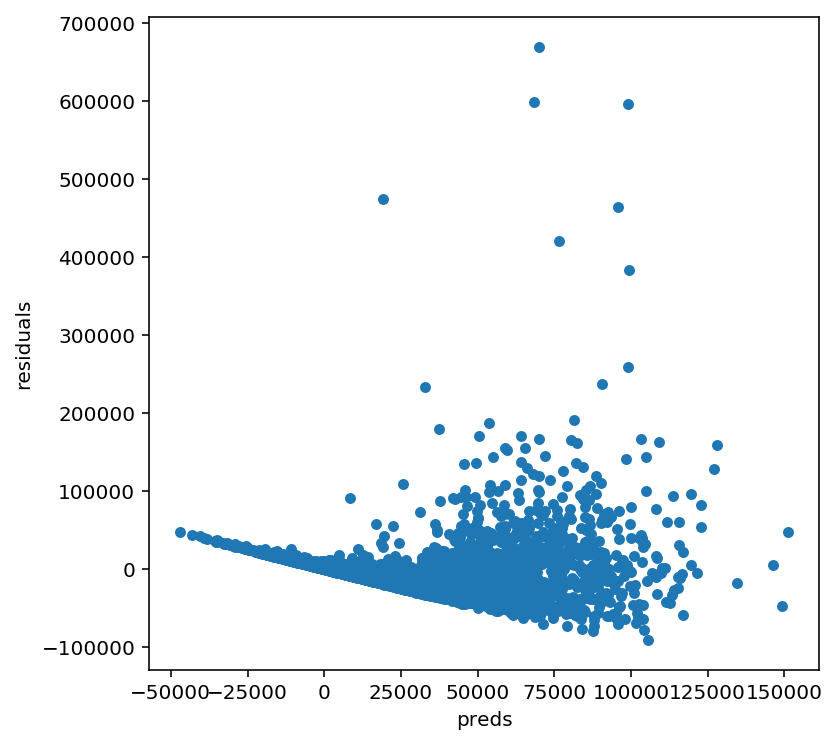

```python
#let's look at the residuals as well:
matplotlib.rcParams['figure.figsize'] = (6.0, 6.0)

preds = pd.DataFrame({"preds":lr_train.predict(X_train), "true":y_train})
preds["residuals"] = preds["true"] - preds["preds"]
preds.plot(x = "preds", y = "residuals",kind = "scatter")
```

### Inerpretation

In relation to coefficients to no surprise we see that budget is a big factor and degrees doesnt matter

Residual plot doesnt look very good. Maybe we are missing something?

The training sample R^2 is not that bad, but is higher than the test sample one. In addition to that training set RMSE is also lower than the testing set one so maybe we got a bit of overfitting going on.

Lets adress this

# Model Tuning

## Train/Validation/Test Split

```python
# intermediate/test split (gives us test set)
X_intermediate, X_test, y_intermediate, y_test = train_test_split(data,
                                                                  target,
                                                                  shuffle=True,
                                                                  test_size=0.2,
                                                                  random_state=15)

# train/validation split (gives us train and validation sets)
X_train, X_validation, y_train, y_validation = train_test_split(X_intermediate,
                                                                y_intermediate,
                                                                shuffle=False,
                                                                test_size=0.25,
                                                                random_state=2018)
```

```python
# delete intermediate variables
del X_intermediate, y_intermediate

# print proportions
print('train: {}% | validation: {}% | test {}%'.format(round(len(y_train)/len(target),2),
                                                       round(len(y_validation)/len(target),2),
                                                       round(len(y_test)/len(target),2)))
```

```
train: 0.6% | validation: 0.2% | test 0.2%
```

```python
from sklearn.linear_model import Ridge, RidgeCV, LassoCV, LassoLarsCV
from sklearn.model_selection import cross_val_score



def calc_train_error(X_train, y_train, model):
    '''returns in-sample error for already fit model.'''
    predictions = model.predict(X_train)
    mse = mean_squared_error(y_train, predictions)
    rmse = np.sqrt(mse)
    return rmse

def calc_validation_error(X_test, y_test, model):
    '''returns out-of-sample error for already fit model.'''
    predictions = model.predict(X_test)
    mse = mean_squared_error(y_test, predictions)
    rmse = np.sqrt(mse)
    return rmse

def calc_metrics(X_train, y_train, X_test, y_test, model):
    '''fits model and returns the RMSE for in-sample error and out-of-sample error'''
    model.fit(X_train, y_train)
    train_error = calc_train_error(X_train, y_train, model)
    validation_error = calc_validation_error(X_test, y_test, model)
    return train_error, validation_error
```

```python
lr = LinearRegression(fit_intercept=True)

train_error, test_error = calc_metrics(X_train, y_train, X_test, y_test, lr)
train_error, test_error = round(train_error, 3), round(test_error, 3)

print('train error: {} | test error: {}'.format(train_error, test_error))
print('train/test: {}'.format(round(train_error/test_error, 2)))
```

```
train error: 38455.88 | test error: 33702.449
train/test: 1.14
```

```python
alphas = [0,0.001, 0.01, 0.05, 0.1, 0.3, 1, 3, 5, 10, 15, 30, 50, 75]
print('All errors are RMSE')
print('-'*76)

new_train_error = []
new_validation_error = []
new_test_error = []


i = 0
for alpha in alphas:
    # instantiate and fit model
    ridge = Ridge(alpha=alpha, fit_intercept=True, random_state=99)
    ridge.fit(X_train, y_train)
    # calculate errors
    new_train_error.append(np.sqrt(mean_squared_error(y_train, ridge.predict(X_train))))
    new_validation_error.append(np.sqrt(mean_squared_error(y_validation, ridge.predict(X_validation))))
    new_test_error.append(np.sqrt(mean_squared_error(y_test, ridge.predict(X_test))))
    # print errors as report
    print('alpha: {:7} | train error: {:5} | val error: {:6} | test error: {}'.
          format(alpha,
                 round(new_train_error[i],3),
                 round(new_validation_error[i],3),
                 round(new_test_error[i],3)))
    i += 1
```

```
All errors are RMSE
----------------------------------------------------------------------------
alpha:       0 | train error: 38455.88 | val error: 32971.123 | test error: 33702.449
alpha:   0.001 | train error: 38455.88 | val error: 32971.077 | test error: 33702.389
alpha:    0.01 | train error: 38455.881 | val error: 32970.664 | test error: 33701.856
alpha:    0.05 | train error: 38455.893 | val error: 32968.842 | test error: 33699.503
alpha:     0.1 | train error: 38455.93 | val error: 32966.604 | test error: 33696.603
alpha:     0.3 | train error: 38456.313 | val error: 32958.074 | test error: 33685.43
alpha:       1 | train error: 38460.274 | val error: 32933.034 | test error: 33651.242
alpha:       3 | train error: 38487.209 | val error: 32892.28 | test error: 33585.538
alpha:       5 | train error: 38526.711 | val error: 32880.369 | test error: 33550.711
alpha:      10 | train error: 38640.196 | val error: 32907.333 | test error: 33528.957
alpha:      15 | train error: 38749.224 | val error: 32963.04 | test error: 33545.863
alpha:      30 | train error: 39005.622 | val error: 33139.227 | test error: 33642.272
alpha:      50 | train error: 39231.046 | val error: 33322.15 | test error: 33763.125
alpha:      75 | train error: 39417.244 | val error: 33485.421 | test error: 33881.149
```

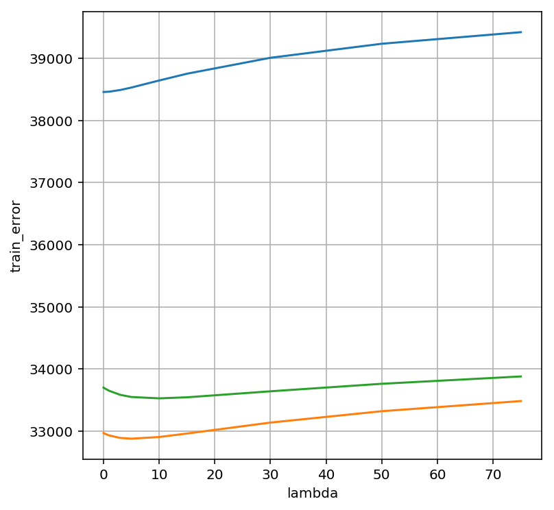

```python
fig, ax = plt.subplots()

ax.plot(alphas, new_train_error)
ax.plot(alphas, new_validation_error)
ax.plot(alphas, new_test_error)

ax.set(xlabel='lambda', ylabel='train_error')
ax.grid()
```

```python
# train/test split
X_train, X_test, y_train, y_test = train_test_split(data,
                                                    target,
                                                    shuffle=True,
                                                    test_size=0.2,
                                                    random_state=15)

# instantiate model
ridge = Ridge(alpha=5, fit_intercept=True, random_state=99)

# fit and calculate errors
new_train_error, new_test_error = calc_metrics(X_train, y_train, X_test, y_test, ridge)
new_train_error, new_test_error = round(new_train_error, 3), round(new_test_error, 3)
```

```python
print('ORIGINAL ERROR')
print('-' * 40)
print('train error: {} | test error: {}\n'.format(train_error, test_error))
print('train/test: {}\n'.format(round(train_error/test_error ,2)))
print('ERROR w/REGULARIZATION')
print('-' * 40)
print('train error: {} | test error: {}'.format(new_train_error, new_test_error))
print('new_train/new_test: {}\n'.format(round(new_train_error/new_test_error ,2)))
```

```
ORIGINAL ERROR
----------------------------------------
train error: 38455.88 | test error: 33702.449

train/test: 1.14

ERROR w/REGULARIZATION
----------------------------------------
train error: 37168.689 | test error: 33464.498
new_train/new_test: 1.11
```

Ok, so the regularization improved our model a bit. But lets try to use *cross validation* instead of a validation set and see if we can improve a bit more.

## Cross Validation

```python
def rmse_cv(model):
    rmse= np.sqrt(-cross_val_score(model, X_train, y_train, scoring="neg_mean_squared_error", cv = 10))
    return(rmse)
```

```python
alphas = [0, 0.01, 0.05, 0.1, 0.3, 1, 3, 5, 10, 15, 30, 50, 75]

val_errors = []


val_errors = [rmse_cv(Ridge(alpha = alpha, fit_intercept=True, random_state=99)).mean()
            for alpha in alphas]
```

```python
cv_ridge = pd.Series(val_errors, index = alphas)
```

```
Text(0,0.5,'rmse')
```

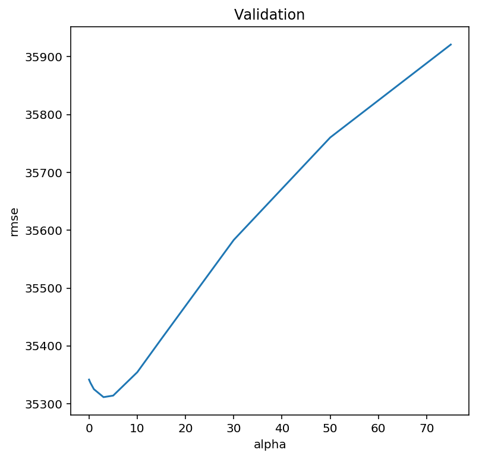

```python
cv_ridge = pd.Series(cv_ridge, index = alphas)
cv_ridge.plot(title = "Validation")
plt.xlabel("alpha")
plt.ylabel("rmse")
```

```python
print('best alpha: {}'.format(alphas[np.argmin(val_errors)]))
```

```
best alpha: 3
```

```python
cv_ridge.min()
```

```
35311.44478845816
```

> sklearn can do it automatically with RidgeCV

```python
from sklearn.linear_model import Ridge, RidgeCV, LassoCV, LassoLarsCV

alphas = [1e-2, 1e-1, 1, 3 ,5 , 1e1, 30, 50, 75, 1e2, 1e3]
model_ridge = RidgeCV(alphas = alphas, fit_intercept=True).fit(X_train, y_train)
```

```python
rmse_cv(model_ridge).mean()
```

```
35304.50063379766
```

```python
pred=model_ridge.predict(X_test) #make prediction on test set
error_test = np.sqrt(mean_squared_error(y_test,pred)) #calculate rmse
error_test
```

```
33488.22019331664
```

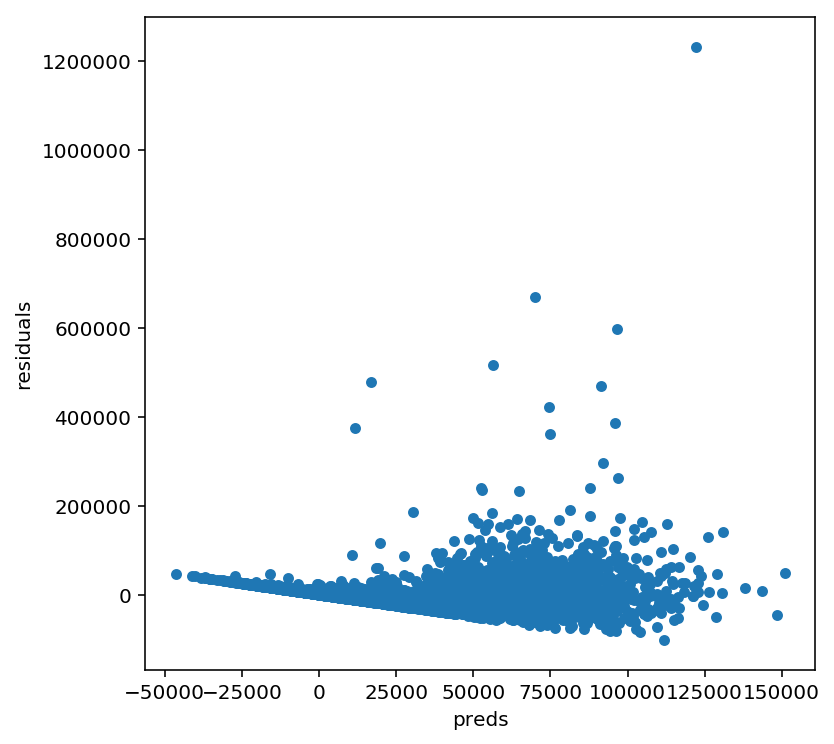

```python
#let's look at the residuals as well:
matplotlib.rcParams['figure.figsize'] = (6.0, 6.0)

preds = pd.DataFrame({"preds":model_ridge.predict(X_train), "true":y_train})
preds["residuals"] = preds["true"] - preds["preds"]
preds.plot(x = "preds", y = "residuals",kind = "scatter")
```

```python
coef = pd.Series(model_ridge.coef_, index = X_train.columns)
```

```
Text(0.5,1,'Coefficients in the Ridge Model')
```

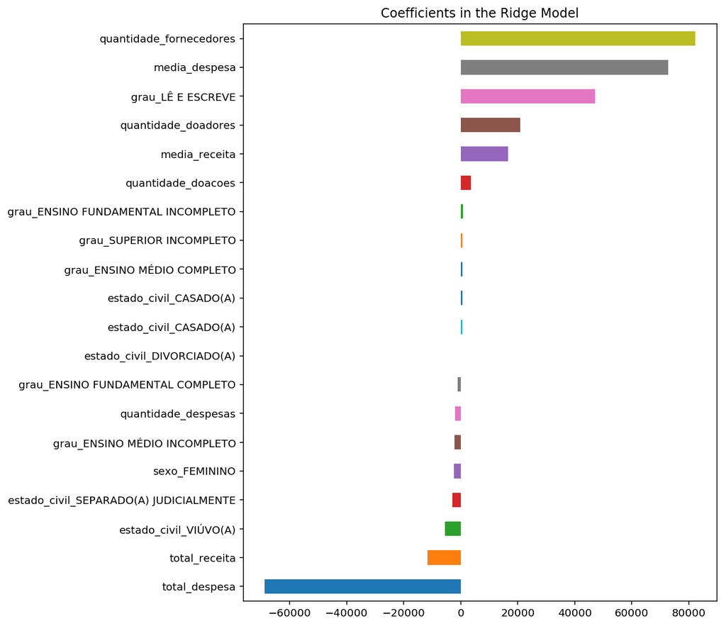

```python
imp_coef = pd.concat([coef.sort_values().head(10),
                     coef.sort_values().tail(10)])

matplotlib.rcParams['figure.figsize'] = (8.0, 10.0)
imp_coef.plot(kind = "barh")
plt.title("Coefficients in the Ridge Model")
```

Now lets try other models

## Model Lasso

```python
alphas = [1e-2, 1e-1, 1, 1e1, 30, 50, 75, 1e2, 1e3]
```

```python
model_lasso = LassoCV(alphas = alphas, max_iter = 10000).fit(X_train, y_train)
```

```python
rmse_cv(model_lasso).mean()
```

```
35291.902589812715
```

```python
print("Lasso picked " + str(sum(coef != 0)) + " variables and eliminated the other " +  str(sum(coef == 0)) + " variables")
```

```
Lasso picked 19 variables and eliminated the other 0 variables
```

```python
imp_coef = pd.concat([coef.sort_values().head(10),
                     coef.sort_values().tail(10)])
```

```
Text(0.5,1,'Coefficients in the Lasso Model')
```

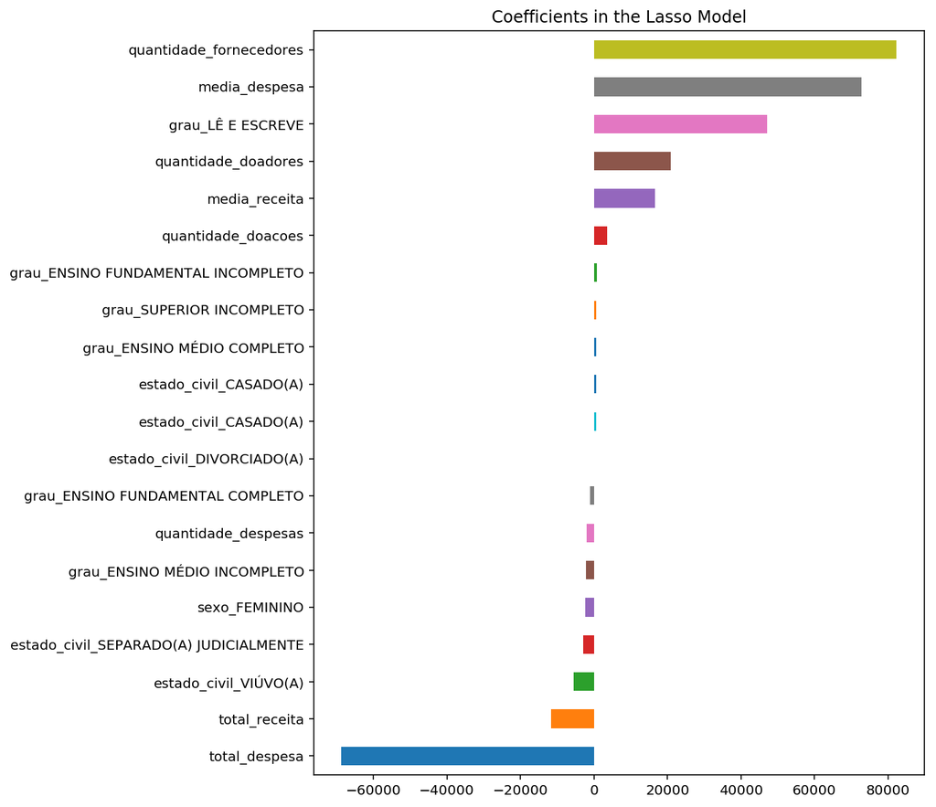

```python
matplotlib.rcParams['figure.figsize'] = (8.0, 10.0)
imp_coef.plot(kind = "barh")
plt.title("Coefficients in the Lasso Model")
```

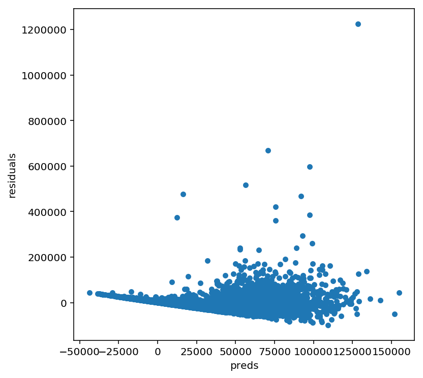

```python
#let's look at the residuals as well:
matplotlib.rcParams['figure.figsize'] = (6.0, 6.0)

preds = pd.DataFrame({"preds":model_lasso.predict(X_train), "true":y_train})
preds["residuals"] = preds["true"] - preds["preds"]
preds.plot(x = "preds", y = "residuals",kind = "scatter")
```

```python
from sklearn import neighbors



# intermediate/test split (gives us test set)
X_intermediate, X_test, y_intermediate, y_test = train_test_split(data,
                                                                  target,
                                                                  shuffle=True,
                                                                  test_size=0.2,
                                                                  random_state=15)

# train/validation split (gives us train and validation sets)
X_train, X_validation, y_train, y_validation = train_test_split(X_intermediate,
                                                                y_intermediate,
                                                                shuffle=False,
                                                                test_size=0.25,
                                                                random_state=2018)

rmse_val = [] #to store rmse values for different k
for K in range(100):
    K = K+1
    model = neighbors.KNeighborsRegressor(n_neighbors = K)

    model.fit(X_train, y_train)  #fit the model
    pred=model.predict(X_validation) #make prediction on test set
    error = np.sqrt(mean_squared_error(y_validation,pred)) #calculate rmse
    rmse_val.append(error) #store rmse values
    print('RMSE value for k= ' , K , 'is:', error)
```

```
RMSE value for k=  1 is: 39022.155486148244
RMSE value for k=  2 is: 34756.42292959455
RMSE value for k=  3 is: 32890.23214382249
RMSE value for k=  4 is: 32429.367827089867
RMSE value for k=  5 is: 31911.067364295333
RMSE value for k=  6 is: 31693.221377738137
RMSE value for k=  7 is: 31298.155113288194
RMSE value for k=  8 is: 31367.587163571276
RMSE value for k=  9 is: 31344.88363136884
RMSE value for k=  10 is: 31031.26904142172
RMSE value for k=  11 is: 30841.89600824522
RMSE value for k=  12 is: 30353.82970955548
RMSE value for k=  13 is: 30270.93451104576
RMSE value for k=  14 is: 30062.27292598865
RMSE value for k=  15 is: 30138.83677512589
RMSE value for k=  16 is: 29951.219276825585
RMSE value for k=  17 is: 29900.022980783626
RMSE value for k=  18 is: 29979.212726350488
RMSE value for k=  19 is: 29874.25444126519
RMSE value for k=  20 is: 29812.093828521844
RMSE value for k=  21 is: 29536.05848957775
RMSE value for k=  22 is: 29558.30722844114
RMSE value for k=  23 is: 29592.19606507514
RMSE value for k=  24 is: 29272.12195330064
RMSE value for k=  25 is: 29311.225701500276
RMSE value for k=  26 is: 29316.302770171384
RMSE value for k=  27 is: 29359.02437729725
RMSE value for k=  28 is: 29359.35588519899
RMSE value for k=  29 is: 29416.591093639967
RMSE value for k=  30 is: 29267.029030932954
RMSE value for k=  31 is: 29242.172402880595
RMSE value for k=  32 is: 29185.06837686025
RMSE value for k=  33 is: 29186.082281604948
RMSE value for k=  34 is: 29144.950405235166
RMSE value for k=  35 is: 29125.020075964367
RMSE value for k=  36 is: 29135.16095494894
RMSE value for k=  37 is: 29136.391865220216
RMSE value for k=  38 is: 29334.02467194531
RMSE value for k=  39 is: 29384.040178351614
RMSE value for k=  40 is: 29337.43049926233
```

[output cut: 45 more lines]

```
RMSE value for k=  86 is: 29429.59177617846
RMSE value for k=  87 is: 29436.313514869536
RMSE value for k=  88 is: 29420.251599056053
RMSE value for k=  89 is: 29406.541463393267
RMSE value for k=  90 is: 29427.154503193433
RMSE value for k=  91 is: 29417.374643093834
RMSE value for k=  92 is: 29406.762377429597
RMSE value for k=  93 is: 29414.226743833653
RMSE value for k=  94 is: 29437.955881373546
RMSE value for k=  95 is: 29452.37062756072
RMSE value for k=  96 is: 29450.50995337481
RMSE value for k=  97 is: 29418.777231381224
RMSE value for k=  98 is: 29454.21011117266
RMSE value for k=  99 is: 29451.602980638072
RMSE value for k=  100 is: 29488.738764944395
```

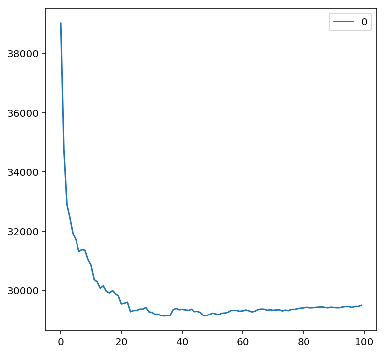

```python
#plotting the rmse values against k values
curve = pd.DataFrame(rmse_val) #elbow curve
curve.plot()
```

```python
knn_model = neighbors.KNeighborsRegressor(n_neighbors = 34)

knn_model.fit(X_train, y_train)



pred=knn_model.predict(X_train) #make prediction on test set
error_train = np.sqrt(mean_squared_error(y_train,pred)) #calculate rmse

pred=knn_model.predict(X_validation) #make prediction on test set
error_validation = np.sqrt(mean_squared_error(y_validation,pred)) #calculate rmse


pred=knn_model.predict(X_test) #make prediction on test set
error_test = np.sqrt(mean_squared_error(y_test,pred)) #calculate rmse

print('TRAIN ERROR')
print('-' * 40)
print(error_train)
print()
print('Validation ERROR')
print('-' * 40)
print(error_validation)
print()
print('TEST ERROR')
print('-' * 40)
print(error_test)
```

```
TRAIN ERROR
----------------------------------------
35048.293027923086

Validation ERROR
----------------------------------------
29144.950405235166

TEST ERROR
----------------------------------------
29677.696631328137
```

```python
from sklearn.model_selection import GridSearchCV
params = {'n_neighbors':[1,2,5,10,15,20,30,40,45,50,55,60]}

knn = neighbors.KNeighborsRegressor()

gs = GridSearchCV(knn, params, cv=5)
gs.fit(X_train,y_train)
gs.best_params_
```

```
{'n_neighbors': 55}
```

```python
pred=gs.predict(X_test)
error = np.sqrt(mean_squared_error(y_test,pred)) #calculate rmse
error
```

```
29809.50241118109
```

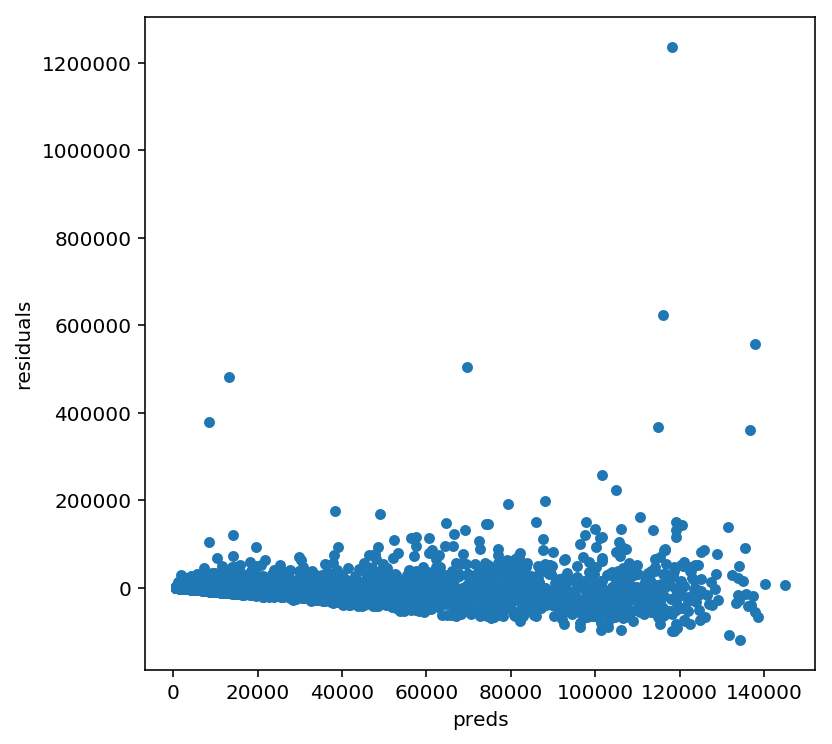

```python
#let's look at the residuals as well:
matplotlib.rcParams['figure.figsize'] = (6.0, 6.0)

preds = pd.DataFrame({"preds":gs.predict(X_train), "true":y_train})
preds["residuals"] = preds["true"] - preds["preds"]
preds.plot(x = "preds", y = "residuals",kind = "scatter")
```

## RANDOM FOREST REGRESSOR

```python
# Import the model we are using
from sklearn.ensemble import RandomForestRegressor

estimators = [1, 10, 100, 1000]

for est in estimators:

    rf = RandomForestRegressor(n_estimators = est, random_state = 42)


    rf.fit(X_train, y_train)  #fit the model
    pred=rf.predict(X_validation) #make prediction on validation set
    error = np.sqrt(mean_squared_error(y_validation,pred)) #calculate rmse

    print('est: ', est , 'validation RMSE is: ', error)
```

```
est:  1 validation RMSE is:  44753.277956957914
est:  10 validation RMSE is:  32865.28168432008
est:  100 validation RMSE is:  30808.53335959843
est:  1000 validation RMSE is:  30851.575774188357
```

```python
rf1 = RandomForestRegressor(n_estimators = 100, random_state = 42)


rf1.fit(X_train, y_train)  #fit the model
pred=rf1.predict(X_test) #make prediction on test set
error = np.sqrt(mean_squared_error(y_test,pred)) #calculate rmse
error
```

```
31653.45869255981
```

```python
rf2 = RandomForestRegressor(n_estimators = 100, random_state = 42, max_depth=10)


rf2.fit(X_train, y_train)  #fit the model
pred=rf2.predict(X_test) #make prediction on test set
```

```python
from sklearn.tree import export_graphviz
import pydot
# Pull out one tree from the forest
tree = rf2.estimators_[5]
# Export the image to a dot file
export_graphviz(tree, out_file = 'tree.dot', feature_names = X_train.columns, rounded = True, precision = 1)
# Use dot file to create a graph
```

```python
(graph, ) = pydot.graph_from_dot_file('tree.dot')
#graph.create_png()
```

```python
from IPython.display import Image
Image("tree.png",unconfined=True)
```

[figure not shown]

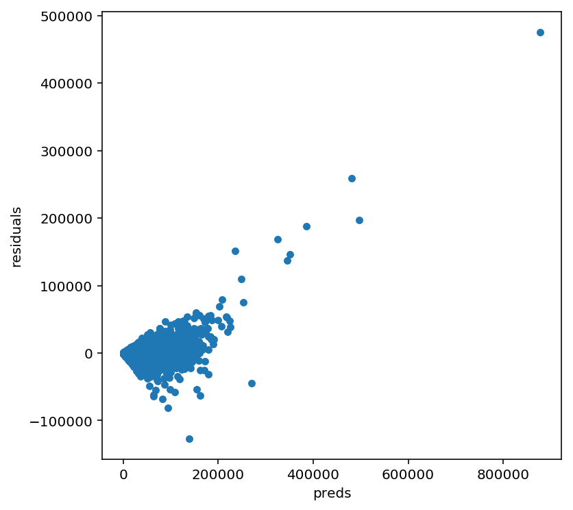

```python
#let's look at the residuals as well:
matplotlib.rcParams['figure.figsize'] = (6.0, 6.0)

preds = pd.DataFrame({"preds":rf.predict(X_train), "true":y_train})
preds["residuals"] = preds["true"] - preds["preds"]
preds.plot(x = "preds", y = "residuals",kind = "scatter")
```

### Comments

Pretty much all models have pretty bad residual plot showing both an unbalanced y axis and heteroscedasticity.

KNN seems to have the lower heteroscedasticity so lets use it when dealing with 2014 data

## 2014 data

```python
uri_2014 = 'eleicoes_2014.csv'

df_2014 = pd.read_csv(uri_2014)

df_2014.head()
```

|  | ano | sq_candidato | nome_candidato | sigla_uf | sigla_partido | qtd_doacoes | qtd_doadores | total_receita | media_receita | recursos de outros candidatos/comitês | ... | qtd_despesas | qtd_fornecedores | total_despesa | media_despesa | descricao_cargo | sexo | grau_instrucao | estado_civil | descricao_ocupacao | votos |
| --- | --- | --- | --- | --- | --- | --- | --- | --- | --- | --- | --- | --- | --- | --- | --- | --- | --- | --- | --- | --- | --- |
| 0 | 2014 | 10000000135 | EMERSON DA SILVA SANTOS | AC | PSOL | 3 | 3 | 1580.00 | 526.666667 | NaN | ... | 3 | 3 | 1580.00 | 526.666667 | DEPUTADO FEDERAL | MASCULINO | ENSINO MÉDIO COMPLETO | SOLTEIRO(A) | CORRETOR DE IMÓVEIS, SEGUROS, TÍTULOS E VALORES | 37 |
| 1 | 2014 | 10000000142 | GERALDO SILVA DOS SANTOS | AC | PSOL | 5 | 5 | 3180.00 | 636.000000 | NaN | ... | 6 | 5 | 3130.02 | 626.004000 | DEPUTADO FEDERAL | MASCULINO | SUPERIOR COMPLETO | SOLTEIRO(A) | VIGILANTE | 383 |
| 2 | 2014 | 10000000158 | CARLOS CESAR CORREIA DE MESSIAS | AC | PSB | 40 | 38 | 333293.13 | 8770.871842 | 1923.07 | ... | 145 | 139 | 326869.78 | 2351.581151 | DEPUTADO FEDERAL | MASCULINO | ENSINO FUNDAMENTAL INCOMPLETO | CASADO(A) | OUTROS | 26448 |
| 3 | 2014 | 10000000161 | IDESIO LUIS FRANKE | AC | PT | 29 | 29 | 156719.32 | 5404.114483 | 39122.32 | ... | 136 | 121 | 241016.07 | 1991.868347 | DEPUTADO FEDERAL | MASCULINO | SUPERIOR COMPLETO | CASADO(A) | AGRÔNOMO | 9896 |
| 4 | 2014 | 10000000163 | LEONARDO CUNHA DE BRITO | AC | PT | 160 | 146 | 711083.00 | 4870.431507 | 10000.00 | ... | 518 | 354 | 567401.15 | 1602.828107 | DEPUTADO FEDERAL | MASCULINO | SUPERIOR COMPLETO | CASADO(A) | ADVOGADO | 20876 |

5 rows × 23 columns

```python
df_2014.rename(columns={'ano': 'ano', 'sq_candidato': 'sequencial_candidato', 'nome_candidato': 'nome', 'sigla_uf': 'uf', 'sigla_partido': 'partido', 'qtd_doacoes': 'quantidade_doacoes', 'qtd_doadores': 'quantidade_doadores', 'total_receita': 'total_receita', 'media_receita': 'media_receita', 'recursos de outros candidatos/comitês': 'recursos_de_outros_candidatos/comites', 'recursos de pessoas físicas': 'recursos_de_pessoas_fisicas', 'recursos de pessoas jurídicas': 'recursos_de_pessoas_juridicas', 'recursos próprios': 'recursos_proprios', 'qtd_despesas': 'quantidade_despesas', 'qtd_fornecedores': 'quantidade_fornecedores', 'total_despesa': 'total_despesa', 'media_despesa': 'media_despesa', 'descricao_cargo': 'cargo', 'sexo': 'sexo', 'grau_instrucao': 'grau', 'estado_civil': 'estado_civil', 'descricao_ocupacao': 'ocupacao', 'votos': 'votos'},
            inplace=True)
```

```python
df_2014.columns
```

```
Index(['ano', 'sequencial_candidato', 'nome', 'uf', 'partido',
       'quantidade_doacoes', 'quantidade_doadores', 'total_receita',
       'media_receita', 'recursos_de_outros_candidatos/comites',
       'recursos_de_pessoas_fisicas', 'recursos_de_pessoas_juridicas',
       'recursos_proprios', 'quantidade_despesas', 'quantidade_fornecedores',
       'total_despesa', 'media_despesa', 'cargo', 'sexo', 'grau',
       'estado_civil', 'ocupacao', 'votos'],
      dtype='object')
```

```python
df_2014.drop(labels=['partido','ano', 'sequencial_candidato', 'nome', 'uf', 'ocupacao', 'cargo' ], axis=1, inplace=True)
```

```python
df_2014.isnull().any()
```

```
quantidade_doacoes                       False
quantidade_doadores                      False
total_receita                            False
media_receita                            False
recursos_de_outros_candidatos/comites     True
recursos_de_pessoas_fisicas               True
recursos_de_pessoas_juridicas             True
recursos_proprios                         True
quantidade_despesas                      False
quantidade_fornecedores                  False
total_despesa                            False
media_despesa                            False
sexo                                     False
grau                                     False
estado_civil                             False
votos                                    False
dtype: bool
```

```python
df_2014.isnull().sum()
```

```
quantidade_doacoes                          0
quantidade_doadores                         0
total_receita                               0
media_receita                               0
recursos_de_outros_candidatos/comites    1745
recursos_de_pessoas_fisicas              1209
recursos_de_pessoas_juridicas            3222
recursos_proprios                        2076
quantidade_despesas                         0
quantidade_fornecedores                     0
total_despesa                               0
media_despesa                               0
sexo                                        0
grau                                        0
estado_civil                                0
votos                                       0
dtype: int64
```

> Pretty similar to previou df, so lets drop the columns

```python
df_2014.drop(labels=['recursos_de_outros_candidatos/comites', 'recursos_de_pessoas_fisicas', 'recursos_de_pessoas_juridicas', 'recursos_proprios'], axis=1, inplace=True)
```

```python
numerics = df_2014[numeric_feats]

numerics.max() - numerics.min()
```

```
quantidade_doacoes         9.270000e+02
quantidade_doadores        8.720000e+02
total_receita              5.836139e+06
media_receita              2.812497e+05
quantidade_despesas        6.412000e+03
quantidade_fornecedores    5.169000e+03
total_despesa              7.420178e+06
media_despesa              3.551977e+04
dtype: float64
```

```python
skewed_feats = df_2014[numeric_feats].apply(lambda x: skew(x.dropna()))
print(skewed_feats)
```

```
quantidade_doacoes         6.086289
quantidade_doadores        6.286061
total_receita              4.580348
media_receita              5.941006
quantidade_despesas        6.338817
quantidade_fornecedores    6.642770
total_despesa              4.756866
media_despesa              6.858381
dtype: float64
```

```python
df[skewed_feats.index] =  np.log1p(df[skewed_feats.index])
```

```python
df_2014 = pd.get_dummies(df_2014)
df_2014.drop(labels=['grau_SUPERIOR COMPLETO', 'estado_civil_SOLTEIRO(A)', 'sexo_MASCULINO'], axis=1, inplace=True)
```

```python
test_2014 = df_2014.copy()
target_2014 = test_2014.pop('votos')
```

```python
from sklearn.model_selection import GridSearchCV
params = {'n_neighbors':[1,2,5,10,15,20,30,40,45,50,55,60]}

knn = neighbors.KNeighborsRegressor()

gs = GridSearchCV(knn, params, cv=5)
gs.fit(data,target)
gs.best_params_
```

```
{'n_neighbors': 55}
```

```python
pred=gs.predict(data)
error = np.sqrt(mean_squared_error(target,pred)) #calculate rmse
error
```

```
32779.79203180367
```

```python
pred=gs.predict(test_2014)
error = np.sqrt(mean_squared_error(target_2014,pred)) #calculate rmse
error
```

```
133542.7075049016
```

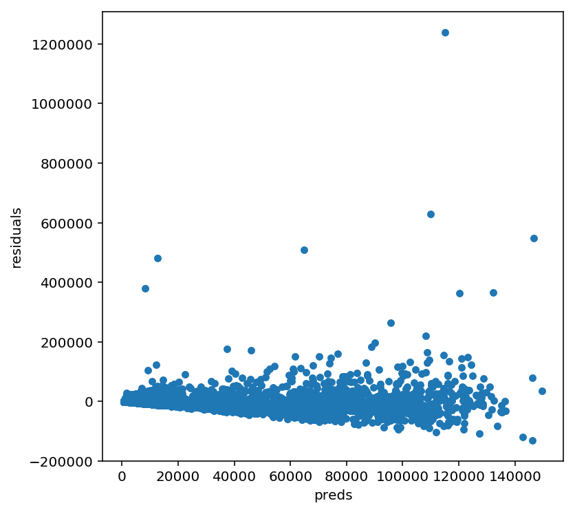

```python
#let's look at the residuals as well:
matplotlib.rcParams['figure.figsize'] = (6.0, 6.0)

preds = pd.DataFrame({"preds":gs.predict(X_train), "true":y_train})
preds["residuals"] = preds["true"] - preds["preds"]
preds.plot(x = "preds", y = "residuals",kind = "scatter")
```

# Conclusion

So after training with 2006 and 2010 data and testing the best model with 2014 we got a big error of 133542. The models are not great probably due to the unbalcade y axis.